# My First Sweet R Markdown Notebook

C.M. Gienger

2022-11-09

This is an example of an [R Markdown](http://rmarkdown.rstudio.com) Notebook. When you execute code within the notebook, the results appear beneath the code. This allows you to have a linear workflow, which will help you collaborate with others more efficiently. The basics of R Markdown can be found [here](https://r4ds.had.co.nz/r-markdown.html). There is also a cheatsheet in the RStudio help menu.

First, lets make a simple graph using some base R code.

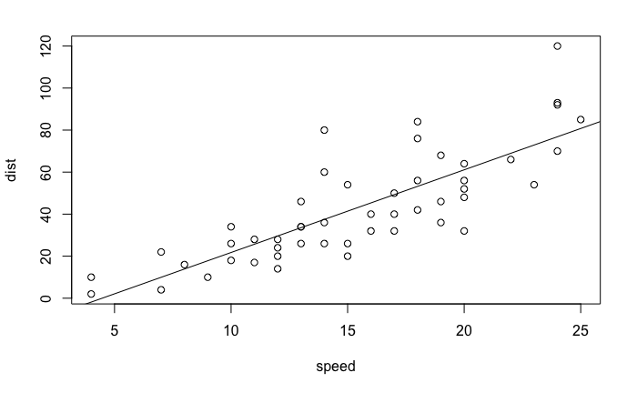

```r
model_1 <- lm(dist ~ speed, data = cars)
plot(dist ~ speed, data = cars)
abline(model_1)
```

Next, we can fit a linear model.

```r
model_2 <- lm(dist ~ speed, data = cars)
anova(model_2)
```

```
Analysis of Variance Table

Response: dist
          Df Sum Sq Mean Sq F value   Pr(>F)
speed      1  21186 21185.5  89.567 1.49e-12 ***
Residuals 48  11354   236.5
---
Signif. codes:  0 ‘***’ 0.001 ‘**’ 0.01 ‘*’ 0.05 ‘.’ 0.1 ‘ ’ 1
```

Lets remake the graph from the diamonds example, using ggplot2 code.

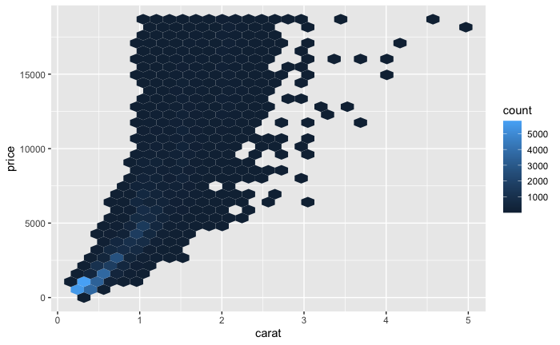

*Inline code to use in displaying results.*

We have data about 53940 diamonds. The average price is 3932.7997219 dollars. Diamonds range from 326 to 18823 dollars.

Lets make a table that displays some of the raw diamond data.

```r
#https://rmarkdown.rstudio.com/lesson-7.html
kable(diamonds[1:20, ], caption = 'Table 1. A knitr kable displaying the first 20 diamonds in the data set.')
```

Table 1. A knitr kable displaying the first 20 diamonds in the data set.

| carat | cut | color | clarity | depth | table | price | x | y | z |
| --- | --- | --- | --- | --- | --- | --- | --- | --- | --- |
| 0.23 | Ideal | E | SI2 | 61.5 | 55 | 326 | 3.95 | 3.98 | 2.43 |
| 0.21 | Premium | E | SI1 | 59.8 | 61 | 326 | 3.89 | 3.84 | 2.31 |
| 0.23 | Good | E | VS1 | 56.9 | 65 | 327 | 4.05 | 4.07 | 2.31 |
| 0.29 | Premium | I | VS2 | 62.4 | 58 | 334 | 4.20 | 4.23 | 2.63 |
| 0.31 | Good | J | SI2 | 63.3 | 58 | 335 | 4.34 | 4.35 | 2.75 |
| 0.24 | Very Good | J | VVS2 | 62.8 | 57 | 336 | 3.94 | 3.96 | 2.48 |
| 0.24 | Very Good | I | VVS1 | 62.3 | 57 | 336 | 3.95 | 3.98 | 2.47 |
| 0.26 | Very Good | H | SI1 | 61.9 | 55 | 337 | 4.07 | 4.11 | 2.53 |
| 0.22 | Fair | E | VS2 | 65.1 | 61 | 337 | 3.87 | 3.78 | 2.49 |
| 0.23 | Very Good | H | VS1 | 59.4 | 61 | 338 | 4.00 | 4.05 | 2.39 |
| 0.30 | Good | J | SI1 | 64.0 | 55 | 339 | 4.25 | 4.28 | 2.73 |
| 0.23 | Ideal | J | VS1 | 62.8 | 56 | 340 | 3.93 | 3.90 | 2.46 |
| 0.22 | Premium | F | SI1 | 60.4 | 61 | 342 | 3.88 | 3.84 | 2.33 |
| 0.31 | Ideal | J | SI2 | 62.2 | 54 | 344 | 4.35 | 4.37 | 2.71 |
| 0.20 | Premium | E | SI2 | 60.2 | 62 | 345 | 3.79 | 3.75 | 2.27 |
| 0.32 | Premium | E | I1 | 60.9 | 58 | 345 | 4.38 | 4.42 | 2.68 |
| 0.30 | Ideal | I | SI2 | 62.0 | 54 | 348 | 4.31 | 4.34 | 2.68 |
| 0.30 | Good | J | SI1 | 63.4 | 54 | 351 | 4.23 | 4.29 | 2.70 |
| 0.30 | Good | J | SI1 | 63.8 | 56 | 351 | 4.23 | 4.26 | 2.71 |
| 0.30 | Very Good | J | SI1 | 62.7 | 59 | 351 | 4.21 | 4.27 | 2.66 |

Lets make a table that summarizes the diamond data.

```r
summary1 <- summarise(group_by(diamonds, cut),
          n=n(),
          mean=mean(price),
          sd=sd(price))
kable(summary1, caption = 'Table 2. A summary kable displaying number, mean, and standard deviation for each of five cuts of diamond.', digits = c(0, 0, 1, 1))
```

Table 2. A summary kable displaying number, mean, and standard deviation for each of five cuts of diamond.

| cut | n | mean | sd |
| --- | --- | --- | --- |
| Fair | 1610 | 4358.8 | 3560.4 |
| Good | 4906 | 3928.9 | 3681.6 |
| Very Good | 12082 | 3981.8 | 3935.9 |
| Premium | 13791 | 4584.3 | 4349.2 |
| Ideal | 21551 | 3457.5 | 3808.4 |

Lets insert a static image, like a picture or figure. Notice that this is inline code, not inside a code chunk.

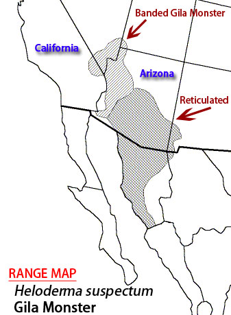

Figure 1. Geographic distribution of the Gila Monster (*Heloderma suspectum*)

Lets make a simple map for our report.

```r
leaflet() %>%
  setView(-87.354841, 36.534942, zoom = 16) %>% #lat-long of the place of interest
  addTiles() %>%
  addMarkers(-87.354841, 36.534942, popup = "APSU")
```

[interactive chart not shown]

Lets embed something totally ridiculous, but cool…

[figure not shown]